# Linear Transformations as Geometry: Projection, Eigen-Directions, and the SVD

**Hady Hosam**

Linear algebra is often introduced through systems of equations, but at its core is the study of linear transformations. The goal of this notebook is to develop intuition for linear transformations by examining how they behave geometrically. We will begin by studying how different matrices transform the plane, then use this geometric viewpoint to understand **projection** and the **least squares** method. From there, we examine **eigenvalues and eigenvectors** as the directions that a transformation preserves, and show how these ideas culminate in the **Singular Value Decomposition**, which expresses any linear map as a combination of rotations and scalings.

### Why this matters

These ideas appear throughout applied mathematics:

- In **data analysis**, projecting data onto lower-dimensional subspaces is the basis of least squares and principal component analysis.
- In **optimization**, positive definite matrices describe curvature and stability.
- In **quantitative modeling**, eigenvalues determine growth, decay, and long-term behavior of dynamic systems.
- In **signal processing and finance**, the SVD and eigen-decompositions extract dominant structure from noisy observations.

## 1. Transformations in the Plane

A matrix represents a linear transformation: it takes vectors in $\mathbb{R}^2$ and maps them to new vectors in $\mathbb{R}^2$. Rather than thinking of a matrix as a list of numbers, it is more helpful to understand it as an operation that reshapes space. Below I examine several representative transformations and describe their algebraic and geometric properties.

### 1.1 Rotation

For an angle $\theta$, the rotation matrix is

$$ R_\theta = \begin{pmatrix} \cos\theta & -\sin\theta \\ \sin\theta & \cos\theta \end{pmatrix}. $$

This matrix is **orthogonal**, meaning

$$ R_\theta^T R_\theta = I. $$

Hence rotation preserves inner products:

$$ \langle R_\theta x, R_\theta y \rangle = \langle x, y \rangle, $$

so lengths and angles remain unchanged. Rotation changes *orientation* but preserves *shape*.

### 1.2 Reflection

Reflection across the vertical axis is represented by

$$ M = \begin{pmatrix} -1 & 0 \\ 0 & 1 \end{pmatrix}. $$

We compute:

$$ M^T M = I, \qquad \det(M) = -1. $$

Thus reflection preserves lengths but **reverses orientation**.

### 1.3 Shear

A shear with parameter $k$ is given by

$$ S = \begin{pmatrix} 1 & k \\ 0 & 1 \end{pmatrix}. $$

The determinant is

$$ \det(S) = 1, $$

so area is preserved, but angles generally are not. Shear distorts shapes while maintaining “volume.” This illustrates that preserving one geometric property does not imply preserving all geometric structure.

### 1.4 Projection onto a Line

Let $u \in \mathbb{R}^2$ be a unit vector. The orthogonal projection onto the line $\operatorname{span}(u)$ is

$$ P = uu^T. $$

Then

$$ P^2 = P, \qquad P^T = P. $$

The transformation sends any vector $x$ to the point $Px$ in $\operatorname{span}(u)$ that is closest to $x$ in Euclidean distance. Thus projection solves the problem of finding the **best approximation** of $x$ from a subspace. This idea will be central when deriving the least squares solution.

## 2. Projection and the Least Squares Problem

We want to solve the system

$$ Ax = b, $$

where $A$ is an $m \times n$ matrix and $b \in \mathbb{R}^m$. If $b$ is not in the column space of $A$, then no exact solution exists. In that case, we look for the **best approximation** to $b$ from $\operatorname{Col}(A)$.

This leads to the **least squares problem**:

$$ \hat{x} = \arg\min_{x \in \mathbb{R}^n} \|Ax - b\|_2^2. $$

Let $\hat{b} = A\hat{x}$ be the approximation to $b$, and let

$$ r = b - \hat{b} $$

be the **residual vector**.

### 2.1 Geometric Interpretation

The vector $\hat{b}$ is the **orthogonal projection** of $b$ onto the column space of $A$, and the residual $r$ is orthogonal to that space:

$$ r \perp \operatorname{Col}(A). $$

Since the columns of $A$ span $\operatorname{Col}(A)$, orthogonality implies

$$ a_i^T r = 0 \quad \text{for each column } a_i \text{ of } A. $$

In matrix form, this is:

$$ A^T r = 0. $$

Substituting $r = b - A\hat{x}$:

$$ A^T(b - A\hat{x}) = 0. $$

Rearranging gives the **normal equations**:

$$ A^T A \hat{x} = A^T b. $$

If $A^TA$ is invertible, the least squares solution is:

$$ \hat{x} = (A^TA)^{-1} A^T b. $$

### 2.2 Interpretation

The vector $A\hat{x}$ is the closest point in the subspace $\operatorname{Col}(A)$ to $b$, and $r$ is the component of $b$ that cannot be represented by combinations of the columns of $A$.

Thus, **least squares is fundamentally a projection problem**, not an algebraic trick.

### 2.3 Visualization: Projection Geometry

To visualize the least squares projection, consider $b \in \mathbb{R}^3$ and a matrix $A$ with two linearly independent columns. The column space $\operatorname{Col}(A)$ is then a plane in $\mathbb{R}^3$. The least squares solution corresponds to the point $\hat{b} = A\hat{x}$ on this plane that is closest to $b$.

The vector $$ r = b - \hat{b} $$ is orthogonal to the plane. The right angle in the diagram is the geometric content of the normal equations.

I construct a simple example and plot the vectors.

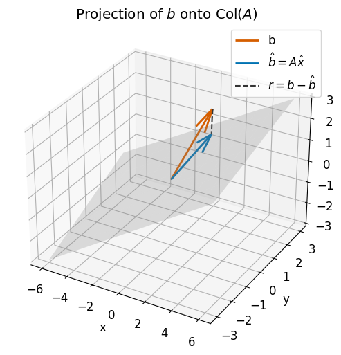

```python
import numpy as np
import matplotlib.pyplot as plt
from mpl_toolkits.mplot3d import Axes3D


plt.rcParams.update({
    "figure.figsize": (6, 6),
    "axes.labelsize": 12,
    "font.size": 12
})

# Define the example matrix
A = np.array([[1, 1],
              [0, 1],
              [1, 0]], dtype=float)

b = np.array([2, 1, 3], dtype=float)

# Least squares solution
x_hat = np.linalg.solve(A.T @ A, A.T @ b)
b_hat = A @ x_hat
r = b - b_hat

# Prepare 3D figure
fig = plt.figure()
ax = fig.add_subplot(111, projection='3d')

# Plot column space plane
u, v = np.linspace(-3, 3, 10), np.linspace(-3, 3, 10)
U, V = np.meshgrid(u, v)
plane = A[:,0:1] @ U.reshape(1,-1) + A[:,1:2] @ V.reshape(1,-1)
X = plane[0].reshape(U.shape)
Y = plane[1].reshape(U.shape)
Z = plane[2].reshape(U.shape)
ax.plot_surface(X, Y, Z, alpha=0.25, color="#bbbbbb")

# Plot vectors
ax.quiver(0,0,0, b[0], b[1], b[2], color="#D55E00", linewidth=2, label="b")
ax.quiver(0,0,0, b_hat[0], b_hat[1], b_hat[2], color="#0072B2", linewidth=2, label=r"$\hat{b}=A\hat{x}$")
ax.quiver(b_hat[0], b_hat[1], b_hat[2],
          r[0], r[1], r[2],
          color="#333333", linestyle='--', linewidth=1.5, label=r"$r=b-\hat{b}$")

ax.set_xlabel('x')
ax.set_ylabel('y')
ax.set_zlabel('z')
ax.set_title(r"Projection of $b$ onto $\operatorname{Col}(A)$")
ax.legend()

plt.show()
```

The point $A\hat{x}$ lies in the column space of $A$, and the residual $r = b - A\hat{x}$ is orthogonal to that space. The right angle in the diagram visually represents the condition

$$ A^T (b - A\hat{x}) = 0, $$

which led to the normal equations. This plot illustrates that least squares is fundamentally a **projection problem**.

## 3. Eigenvalues and Eigenvectors

A linear transformation typically changes the direction of a vector. However, some vectors point in directions that are preserved under the transformation. These are the **eigenvectors** of the matrix.

### 3.1 Definition

A nonzero vector $v$ is an eigenvector of a matrix $A$ if

$$ A v = \lambda v, $$

for some scalar $\lambda$, called the **eigenvalue**. The vector keeps its direction, and $\lambda$ describes how its length is scaled.

Eigenvectors reveal the **principal geometric directions** of a linear transformation.

### 3.2 Symmetric Matrix Example

Consider

$$ A = \begin{pmatrix} 3 & 1 \\ 1 & 3 \end{pmatrix}. $$

Since $A$ is **symmetric**, the spectral theorem guarantees that:

- all eigenvalues are real, and
- there exists an orthonormal basis of eigenvectors.

To find the eigenvalues, compute the characteristic polynomial:

$$ \det(A - \lambda I) = \begin{vmatrix} 3 - \lambda & 1 \\ 1 & 3 - \lambda \end{vmatrix} = (3 - \lambda)^2 - 1. $$

Expanding:

$$ (3 - \lambda)^2 - 1 = \lambda^2 - 6\lambda + 8. $$

Solving $\lambda^2 - 6\lambda + 8 = 0$ gives

$$ \lambda_1 = 4, \qquad \lambda_2 = 2. $$

To find the corresponding eigenvectors:

For $\lambda = 4$:

$$ (A - 4I)v = 0 \quad \Rightarrow \quad \begin{pmatrix} -1 & 1 \\ 1 & -1 \end{pmatrix} v = 0, $$

which gives $v_1 = (1, 1)^T$.

For $\lambda = 2$:

$$ (A - 2I)v = 0 \quad \Rightarrow \quad \begin{pmatrix} 1 & 1 \\ 1 & 1 \end{pmatrix} v = 0, $$

which gives $v_2 = (1, -1)^T$.

Normalizing:

$$ u_1 = \frac{1}{\sqrt{2}} \begin{pmatrix} 1 \\ 1 \end{pmatrix}, \qquad u_2 = \frac{1}{\sqrt{2}} \begin{pmatrix} 1 \\ -1 \end{pmatrix}. $$

Thus, $A$ stretches space by a factor of $4$ along $u_1$ and by a factor of $2$ along $u_2$.

### 3.3 Repeated Application and Dominant Directions

Any vector $x$ in $\mathbb{R}^2$ can be written in the eigenbasis:

$$ x = c_1 u_1 + c_2 u_2. $$

Then:

$$ A^k x = c_1 (4^k) u_1 + c_2 (2^k) u_2. $$

As $k \to \infty$, the term involving $4^k$ dominates:

$$ \frac{A^k x}{\|A^k x\|} \to u_1. $$

This shows that under repeated application of $A$, every vector (except those orthogonal to $u_1$) converges in direction to the eigenvector corresponding to the **largest eigenvalue**.

This behavior is the basis of the **power method**, used in numerical linear algebra to compute dominant eigenvectors.

### 3.4 Interpretation

- Eigenvectors describe **stable geometric directions**.
- Eigenvalues quantify **how strongly** the transformation acts along those directions.
- For symmetric matrices, eigenvectors form an **orthonormal coordinate system** that diagonalizes the transformation.

### 3.5 Demonstration: Repeated Application and Convergence in Direction

I illustrate the iteration $$ x_{k+1} = \frac{A x_k}{\|A x_k\|} $$ for the symmetric matrix $$ A = \begin{pmatrix} 3 & 1 \\ 1 & 3 \end{pmatrix}. $$ If $x_0$ has a nonzero component along the eigenvector $u_1$ associated with the largest eigenvalue $\lambda_1=4$, then $x_k$ converges in direction to $u_1$ as $k$ increases.

We can visualize two things:

1. The **trajectory of directions** $x_k/\|x_k\|$ on the unit circle.
2. The **angle** between $x_k$ and $u_1$ decaying to zero.

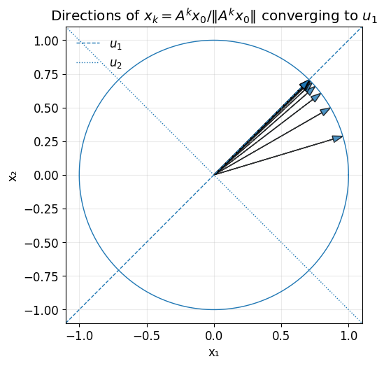

```python
import numpy as np
import matplotlib.pyplot as plt

# Matrix A
A = np.array([[3.0, 1.0],
              [1.0, 3.0]])

# Eigen-decomposition
evals, evecs = np.linalg.eigh(A)
u2 = evecs[:, 0]
u1 = evecs[:, 1]

# Normalize helper
def normalize(x):
    n = np.linalg.norm(x)
    return x / n if n > 0 else x


x0 = normalize(np.array([1.0, 0.3]))
K  = 10  # number of iterations

xs = [x0]
for _ in range(K):
    xs.append(normalize(A @ xs[-1]))

# Unit circle for reference
theta = np.linspace(0, 2*np.pi, 400)
circle = np.vstack([np.cos(theta), np.sin(theta)])

# Plot: directions on unit circle with iterates
plt.figure(figsize=(5.5, 5.5))
plt.plot(circle[0], circle[1], linewidth=1.0)                     # unit circle
plt.axline((0,0), (u1[0], u1[1]), linestyle='--', linewidth=1.0, label=r"$u_1$")
plt.axline((0,0), (u2[0], u2[1]), linestyle=':',  linewidth=1.0, label=r"$u_2$")

# Draw the iterates as arrows from the origin
for k, x in enumerate(xs):
    plt.arrow(0, 0, x[0], x[1], length_includes_head=True, head_width=0.05, alpha=0.8)

plt.gca().set_aspect('equal', adjustable='box')
plt.xlabel("x₁")
plt.ylabel("x₂")
plt.title(r"Directions of $x_k = A^k x_0 / \|A^k x_0\|$ converging to $u_1$")
plt.legend(frameon=False)
plt.grid(True, alpha=0.25)
plt.show()
```

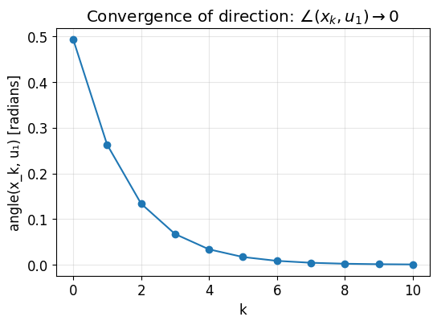

```python
import numpy as np
import matplotlib.pyplot as plt

def angle_to(v, u):
    """Return the angle in radians between nonzero vectors v and u."""
    v = v / np.linalg.norm(v)
    u = u / np.linalg.norm(u)
    # Clip for numerical safety
    c = np.clip(np.dot(v, u), -1.0, 1.0)
    return np.arccos(c)

# Track angles between A^k, x0 and u1
angles = []
x = x0.copy()
for k in range(K+1):
    ang = angle_to(x, u1)
    angles.append(ang)
    x = A @ x  # (unnormalized step for the angle trend)

# Plot the angle (in radians) vs k
plt.figure(figsize=(6, 4))
plt.plot(range(K+1), angles, marker='o')
plt.xlabel("k")
plt.ylabel("angle(x_k, u₁) [radians]")
plt.title(r"Convergence of direction: $\angle(x_k, u_1) \to 0$")
plt.grid(True, alpha=0.3)
plt.show()
```

**Observation:**

Since $x_0 = c_1 u_1 + c_2 u_2$, we have $$ A^k x_0 = c_1 4^k u_1 + c_2 2^k u_2, $$ so after normalization the $4^k$ term dominates. Therefore $x_k / \|x_k\| \to u_1$. The plots confirm this: directions align with $u_1$, and the angle to $u_1$ decreases monotonically.

## 4. Positive Definite Matrices and Quadratic Forms

A real symmetric matrix $A$ defines a scalar function on $\mathbb{R}^n$: $$ q(x) = x^T A x. $$ This is called a **quadratic form**. The shape of $q(x)$ reflects the geometric action of $A$.

### 4.1 Definition

A symmetric matrix $A$ is **positive definite** if $$ x^T A x > 0 \quad \text{for all } x \ne 0. $$

Equivalently:

- all eigenvalues of $A$ are positive, and
- $A$ has an orthonormal eigenbasis.

Thus, positive definite matrices are exactly those that **stretch space in every direction**, never reversing or flattening it.

### 4.2 Diagonalization and Geometry

Let $A$ be symmetric. Then there exists an orthonormal matrix $Q$ and diagonal matrix $\Lambda$ such that: $$ A = Q \Lambda Q^T. $$

Substituting into the quadratic form: $$ x^T A x = (Q^T x)^T \Lambda (Q^T x). $$

Let $y = Q^T x$ (a rotation of coordinates). Then: $$ x^T A x = \lambda_1 y_1^2 + \cdots + \lambda_n y_n^2. $$

This shows that positive definite matrices produce **ellipsoids**, with principal axes aligned with eigenvectors and axis lengths determined by eigenvalues.

### 4.3 Example in $\mathbb{R}^2$

Consider $$ A = \begin{pmatrix} 4 & 1 \\ 1 & 2 \end{pmatrix}. $$

Since $A$ is symmetric and its eigenvalues are positive, the level set $$ x^T A x = 1 $$ is an **ellipse**. The major and minor axes of the ellipse align with the eigenvectors of $A$, and their lengths are inversely proportional to the square roots of the eigenvalues.

### 4.4 Interpretation

- The quadratic form $x^T A x$ measures a type of **energy** associated with $x$.
- In optimization, positive definiteness of the Hessian guarantees **a unique local minimum**.
- In dynamical systems, positive definite matrices are used to construct **Lyapunov functions** for stability analysis.

Thus, positive definiteness connects linear algebra to **curvature, stability, and optimization**, and provides the geometric foundation needed for the singular value decomposition.

### 4.5 Visualization: Level set $x^\top A x = 1$

For a symmetric positive definite matrix $A$, the level set $x^\top A x = 1$ is an ellipse in $\mathbb{R}^2$.  
If $A = Q \Lambda Q^\top$ with eigenvalues $\lambda_1,\lambda_2 > 0$ and orthonormal eigenvectors $q_1, q_2$, then the ellipse has principal axes along $q_1, q_2$ with semi-axis lengths $1/\sqrt{\lambda_1}$ and $1/\sqrt{\lambda_2}$, respectively.

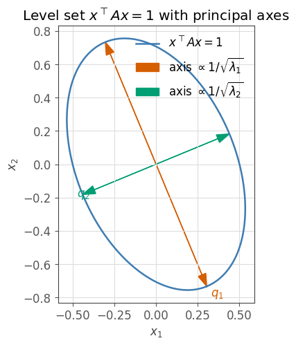

```python
import numpy as np
import matplotlib.pyplot as plt

# Symmetric positive definite example
A = np.array([[4.0, 1.0],
              [1.0, 2.0]])

# Eigendecomposition
lam, Q = np.linalg.eigh(A)           # lam = [λ1, λ2] > 0, columns of Q are eigenvectors
Lam_inv_sqrt = np.diag(1.0 / np.sqrt(lam))

# Parametrize the ellipse x^T A x = 1 as x = Q Λ^{-1/2} u, with ||u|| = 1
theta = np.linspace(0, 2*np.pi, 400)
U = np.vstack([np.cos(theta), np.sin(theta)])           # unit circle
X = Q @ Lam_inv_sqrt @ U                                # ellipse points

# Principal axes (endpoints on the ellipse)
a1 = (1.0 / np.sqrt(lam[0])) * Q[:, 0]
a2 = (1.0 / np.sqrt(lam[1])) * Q[:, 1]

# Styling
plt.rcParams.update({
    "figure.figsize": (5.8, 5.2),
    "axes.edgecolor": "#444444",
    "axes.labelcolor": "#444444",
    "xtick.color": "#555555",
    "ytick.color": "#555555",
    "grid.color": "#dddddd",
    "axes.grid": True,
    "font.size": 12
})

fig, ax = plt.subplots()

# Ellipse
ax.plot(X[0], X[1], linewidth=1.8, color="#3E7CB1", label=r"$x^\top A x = 1$")

# Draw principal axes (both directions)
ax.arrow(0, 0,  a1[0],  a1[1], width=0.0, head_width=0.05, color="#D55E00", length_includes_head=True)
ax.arrow(0, 0, -a1[0], -a1[1], width=0.0, head_width=0.05, color="#D55E00", length_includes_head=True, label=r"axis $\propto 1/\sqrt{\lambda_1}$")

ax.arrow(0, 0,  a2[0],  a2[1], width=0.0, head_width=0.05, color="#009E73", length_includes_head=True)
ax.arrow(0, 0, -a2[0], -a2[1], width=0.0, head_width=0.05, color="#009E73", length_includes_head=True, label=r"axis $\propto 1/\sqrt{\lambda_2}$")

# Basis vectors labels
ax.text(a1[0]*1.08, a1[1]*1.08, r"$q_1$", color="#D55E00")
ax.text(a2[0]*1.08, a2[1]*1.08, r"$q_2$", color="#009E73")

ax.set_aspect("equal", adjustable="box")
ax.set_xlabel(r"$x_1$")
ax.set_ylabel(r"$x_2$")
ax.set_title(r"Level set $x^\top A x = 1$ with principal axes")
ax.legend(frameon=False, loc="upper right")
plt.show()
```

The curve shown is the set of points satisfying $x^\top A x = 1$ for a symmetric positive definite matrix $A$.

Because $A$ is symmetric, it admits an orthonormal eigenbasis. After rotating coordinates into this basis, the quadratic form becomes $$ x^\top A x = \lambda_1 y_1^2 + \lambda_2 y_2^2, $$ where $y = Q^\top x$. The level set $x^\top A x = 1$ is therefore described by $$ \lambda_1 y_1^2 + \lambda_2 y_2^2 = 1, $$ which is the equation of an ellipse.

A larger eigenvalue corresponds to **greater stretching** in the quadratic form and therefore a **shorter** axis in the ellipse. The geometry reflects the curvature structure encoded by $A$.

## 5. Singular Value Decomposition (SVD)

The eigen-decomposition provides a complete geometric description of a **symmetric** matrix. The singular value decomposition (SVD) extends this idea to **all** real matrices, including non-symmetric and non-square ones.

### 5.1 Statement of the SVD

For any real $m \times n$ matrix $A$, there exist orthonormal matrices $U \in \mathbb{R}^{m \times m}$ and $V \in \mathbb{R}^{n \times n}$, and a diagonal matrix $\Sigma \in \mathbb{R}^{m \times n}$ with nonnegative entries such that

$$ A = U \, \Sigma \, V^\top. $$

The diagonal entries $\sigma_1 \ge \sigma_2 \ge \dots \ge 0$ are the **singular values** of $A$. The columns of $V$ are the **right singular vectors**, which form an orthonormal basis of input directions. The columns of $U$ are the **left singular vectors**, which form an orthonormal basis of output directions.

### 5.2 Geometric Interpretation

The decomposition separates the action of $A$ into three conceptually distinct steps:

1. **$V^\top$** — rotates the coordinate system to align with principal input directions.
2. **$\Sigma$** — scales these directions by the singular values $\sigma_i$.
3. **$U$** — rotates the result into the final orientation.

Any linear transformation is a rotation, followed by axis-aligned stretching, followed by another rotation.**

### 5.3 Relation to Quadratic Forms

If $A$ is symmetric positive definite, then the singular value decomposition coincides with the eigen-decomposition:

$$ A = Q \Lambda Q^\top, $$

where $\Lambda$ contains eigenvalues and $Q$ contains orthonormal eigenvectors. In this case, the singular values are $\sigma_i = \lambda_i$, and the level set $x^\top A x = 1$ is the ellipse with axes aligned to those eigenvectors.

For general matrices, SVD plays the role that diagonalization plays for symmetric matrices: it identifies the **principal directions** in which the transformation acts.

### 5.4 Geometric Example

The SVD explains *why* this happens:

- $V^\top$ rotates the circle so that its axes match the principal input directions.
- $\Sigma$ stretches the axes by $\sigma_1$ and $\sigma_2$.
- $U$ rotates the stretched shape to its final orientation.

This mirrors the interpretation of quadratic forms, but holds for all matrices, not only symmetric ones.

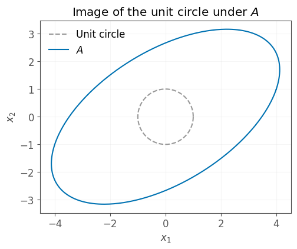

```python
import numpy as np
import matplotlib.pyplot as plt

# Example matrix (non symmetric)
A = np.array([[4, 1],
              [1, 3]], dtype=float)

# Compute SVD
U, S, Vt = np.linalg.svd(A)

# Unit circle
theta = np.linspace(0, 2*np.pi, 400)
circle = np.vstack([np.cos(theta), np.sin(theta)])

# Apply A to the circle
ellipse = A @ circle

plt.figure(figsize=(5.5, 5.5))
plt.plot(circle[0], circle[1], color="#999999", linestyle="--", label="Unit circle")
plt.plot(ellipse[0], ellipse[1], color="#0072B2", label=r"$A$")

plt.gca().set_aspect("equal", adjustable="box")
plt.xlabel("$x_1$")
plt.ylabel("$x_2$")
plt.title(r"Image of the unit circle under $A$")
plt.legend(frameon=False)
plt.grid(alpha=0.25)
plt.show()
```

The image of the unit circle under $A$ is an ellipse. The singular vectors of $A$ determine the directions of its principal axes, and the singular values determine the axis lengths. The SVD expresses this structure explicitly as $A = U\Sigma V^\top$.

## 7. Conclusion

The central idea of this notebook has been that linear algebra is fundamentally geometric. A matrix does not merely transform coordinates; it reshapes space. Viewing linear transformations in this way allows different concepts to connect naturally: projection arises from seeking the closest point in a subspace, eigenvectors identify the directions in which a transformation acts most simply, and the singular value decomposition expresses any transformation as a rotation–scaling–rotation sequence.

### Reference:

Concepts and geometric interpretations were influenced by:  
Gilbert Strang, *Introduction to Linear Algebra*, 5th ed. Wellesley–Cambridge Press.